# Forecasting Office Rental Market in Melbourne CBD

# 1 Forecasting Using Rent Data

## 1.1 Comparing Different Models

### 1.1.1 Mean Absolute Percentage Error of Different Models

The below table and bar chart present the MAPE for different models. Based on the obtained results, the Seasonal-Arima with explanatory variables is the best model.

|  | MAPE (%) |
| --- | --- |
| Holt | 4.35 |
| Holt-Winers | 4.63 |
| Damped Holt-Winters | 5.17 |
| S-ARIMA | 4.28 |
| S-ARIMA with Explanatories | 2.39 |

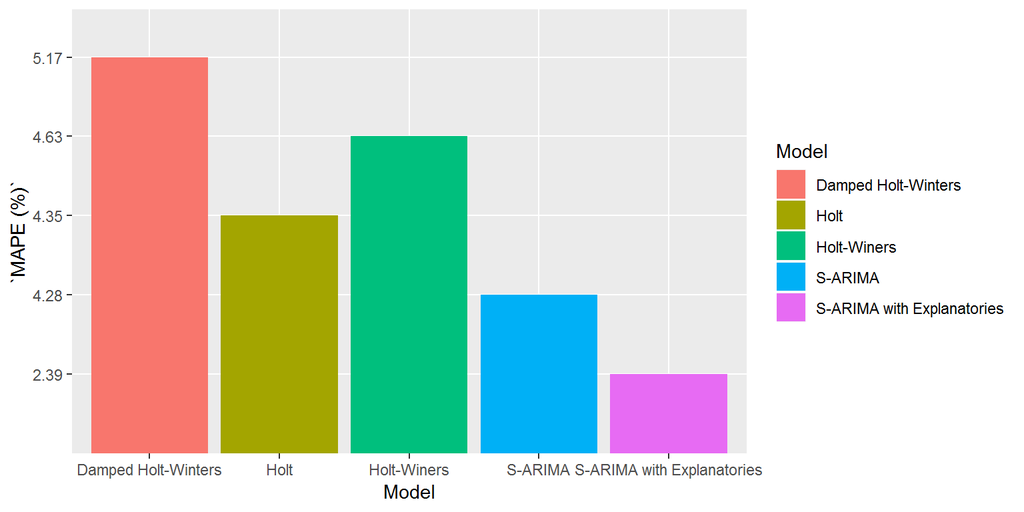

## 1.2 Forecast 1: Holt’s Linear Trend Method

Holt (1957) extended simple exponential smoothing to allow the forecasting of data with a trend. This method involves a forecast equation and two smoothing equations (one for the level and one for the trend. The forecast function is no longer flat but trending. The h-step-ahead forecast is equal to the last estimated level plus h times the last estimated trend value. Hence the forecasts are a linear function of h.

### 1.2.1 Graph

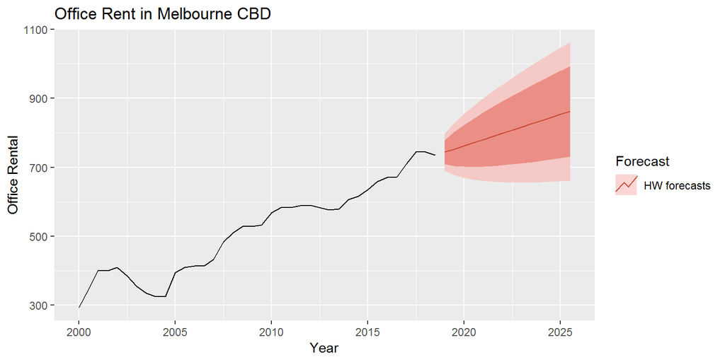

### 1.2.2 Forecast Table

| Date | Mean | Lower.80 | Lower.95 | Upper.80 | Upper.95 |
| --- | --- | --- | --- | --- | --- |
| 2019.0 | 744.0925 | 709.0186 | 690.4516 | 779.1664 | 797.7334 |
| 2019.5 | 753.1831 | 703.5810 | 677.3233 | 802.7851 | 829.0428 |
| 2020.0 | 762.2736 | 701.5217 | 669.3615 | 823.0256 | 855.1857 |
| 2020.5 | 771.3642 | 701.2108 | 664.0739 | 841.5175 | 878.6545 |
| 2021.0 | 780.4548 | 702.0173 | 660.4950 | 858.8922 | 900.4145 |
| 2021.5 | 789.5453 | 703.6173 | 658.1297 | 875.4734 | 920.9610 |
| 2022.0 | 798.6359 | 705.8184 | 656.6838 | 891.4534 | 940.5880 |
| 2022.5 | 807.7265 | 708.4955 | 655.9658 | 906.9575 | 959.4872 |
| 2023.0 | 816.8171 | 711.5614 | 655.8424 | 922.0727 | 977.7917 |
| 2023.5 | 825.9076 | 714.9529 | 656.2169 | 936.8624 | 995.5983 |
| 2024.0 | 834.9982 | 718.6220 | 657.0161 | 951.3744 | 1012.9803 |
| 2024.5 | 844.0888 | 722.5316 | 658.1831 | 965.6459 | 1029.9944 |
| 2025.0 | 853.1793 | 726.6522 | 659.6728 | 979.7065 | 1046.6859 |
| 2025.5 | 862.2699 | 730.9598 | 661.4485 | 993.5800 | 1063.0914 |

### 1.2.3 Residuals

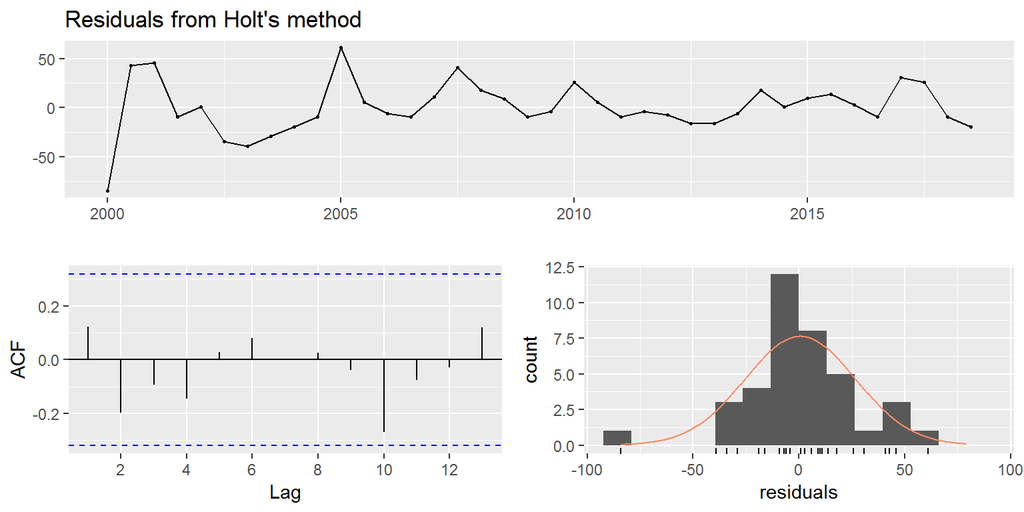

```
##
##  Ljung-Box test
##
## data:  Residuals from Holt's method
## Q* = 3.9111, df = 3, p-value = 0.2712
##
## Model df: 4.   Total lags used: 7
```

### 1.2.4 Goodness of Fit

| AIC | BIC | LogLik |
| --- | --- | --- |
| 395.515 | 403.7029 | -192.7575 |

## 1.3 Forecast 2: Holt-Winters’ Seasonal Method

Holt (1957) and Winters (1960) extended Holt’s method to capture seasonality. The Holt-Winters seasonal method comprises the forecast equation and three smoothing equations. There are two variations to this method that differ in the nature of the seasonal component.

The additive method is preferred when the seasonal variations are roughly constant through the series, while the multiplicative method is preferred when the seasonal variations are changing proportional to the level of the series. With the additive method, the seasonal component is expressed in absolute terms in the scale of the observed series, and in the level equation the series is seasonally adjusted by subtracting the seasonal component. Within each year, the seasonal component will add up to approximately zero. With the multiplicative method, the seasonal component is expressed in relative terms (percentages), and the series is seasonally adjusted by dividing through by the seasonal component. Within each year, the seasonal component will sum up to approximately m.

### 1.3.1 Graph

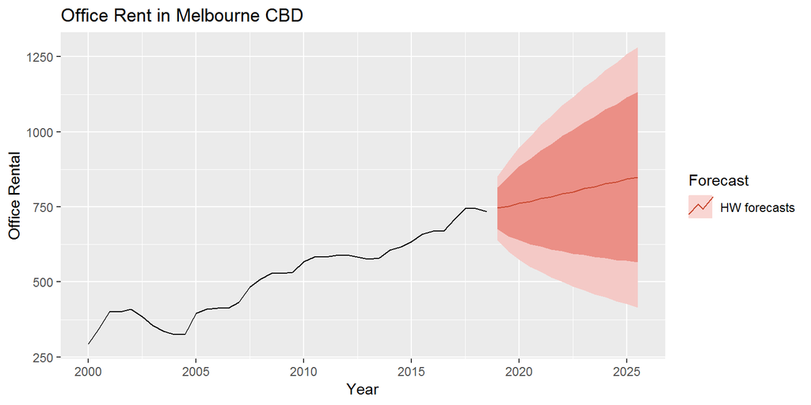

### 1.3.2 Forecast Table

| Date | Mean | Lower.80 | Lower.95 | Upper.80 | Upper.95 |
| --- | --- | --- | --- | --- | --- |
| 2019.0 | 745.7608 | 676.0346 | 639.1237 | 815.4870 | 852.3978 |
| 2019.5 | 751.2682 | 652.3386 | 599.9684 | 850.1979 | 902.5680 |
| 2020.0 | 762.0869 | 639.6624 | 574.8547 | 884.5114 | 949.3191 |
| 2020.5 | 767.5368 | 625.7152 | 550.6393 | 909.3585 | 984.4344 |
| 2021.0 | 778.4130 | 618.2115 | 533.4059 | 938.6145 | 1023.4201 |
| 2021.5 | 783.8055 | 607.7537 | 514.5575 | 959.8572 | 1053.0534 |
| 2022.0 | 794.7391 | 602.6260 | 500.9274 | 986.8523 | 1088.5509 |
| 2022.5 | 800.0741 | 594.0523 | 484.9909 | 1006.0959 | 1115.1573 |
| 2023.0 | 811.0653 | 590.3116 | 473.4516 | 1031.8190 | 1148.6789 |
| 2023.5 | 816.3427 | 582.9305 | 459.3695 | 1049.7550 | 1173.3160 |
| 2024.0 | 827.3914 | 580.0970 | 449.1872 | 1074.6858 | 1205.5956 |
| 2024.5 | 832.6114 | 573.5383 | 436.3933 | 1091.6844 | 1228.8294 |
| 2025.0 | 843.7176 | 571.3384 | 427.1496 | 1116.0967 | 1260.2855 |
| 2025.5 | 848.8800 | 565.3775 | 415.3004 | 1132.3825 | 1282.4597 |

### 1.3.3 Residuals

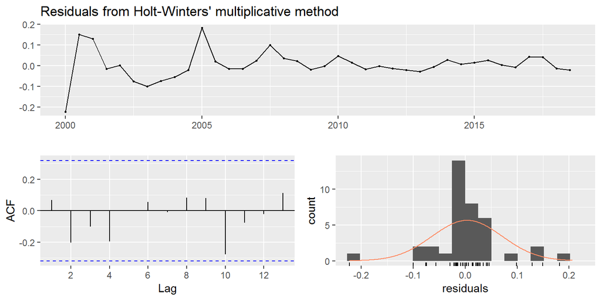

```
##
##  Ljung-Box test
##
## data:  Residuals from Holt-Winters' multiplicative method
## Q* = 4.8915, df = 3, p-value = 0.1799
##
## Model df: 6.   Total lags used: 9
```

### 1.3.4 Goodness of Fit

| AIC | BIC | LogLik |
| --- | --- | --- |
| 418.991 | 430.4541 | -202.4955 |

## 1.4 Forecast 3: Damped Holt-Winters’ Seasonal Method

Damped trend methods: The forecasts generated by Holt’s linear method display a constant trend (increasing or decreasing) indefinitely into the future. Empirical evidence indicates that these methods tend to over-forecast, especially for longer forecast horizons. Motivated by this observation, Gardner & McKenzie (1985) introduced a parameter that “dampens” the trend to a flat line some time in the future. Methods that include a damped trend have proven to be very successful, and are arguably the most popular individual methods when forecasts are required automatically for many series.

### 1.4.1 Graph

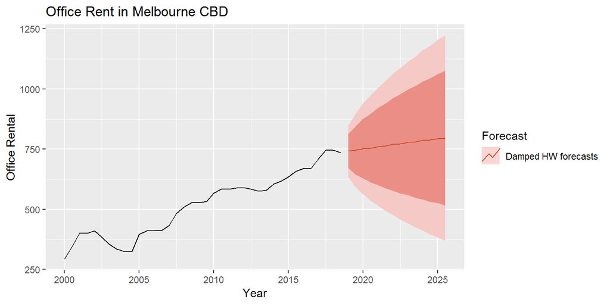

### 1.4.2 Forecast Table

| Date | Mean | Lower.80 | Lower.95 | Upper.80 | Upper.95 |
| --- | --- | --- | --- | --- | --- |
| 2019.0 | 741.9446 | 671.2810 | 633.8739 | 812.6082 | 850.0152 |
| 2019.5 | 744.7555 | 644.6312 | 591.6285 | 844.8799 | 897.8825 |
| 2020.0 | 751.5315 | 627.9978 | 562.6031 | 875.0651 | 940.4599 |
| 2020.5 | 754.1251 | 611.2191 | 535.5693 | 897.0312 | 972.6810 |
| 2021.0 | 760.7387 | 599.8019 | 514.6071 | 921.6756 | 1006.8704 |
| 2021.5 | 763.1237 | 586.5204 | 493.0323 | 939.7271 | 1033.2152 |
| 2022.0 | 769.5814 | 577.4600 | 475.7571 | 961.7028 | 1063.4057 |
| 2022.5 | 771.7660 | 566.0437 | 457.1408 | 977.4884 | 1086.3912 |
| 2023.0 | 778.0740 | 558.3299 | 442.0044 | 997.8180 | 1114.1435 |
| 2023.5 | 780.0661 | 548.0789 | 425.2723 | 1012.0533 | 1134.8599 |
| 2024.0 | 786.2302 | 541.2237 | 411.5250 | 1031.2367 | 1160.9354 |
| 2024.5 | 788.0375 | 531.7664 | 396.1047 | 1044.3086 | 1179.9703 |
| 2025.0 | 794.0635 | 525.4933 | 383.3209 | 1062.6336 | 1204.8061 |
| 2025.5 | 795.6932 | 516.6067 | 368.8672 | 1074.7798 | 1222.5193 |

### 1.4.3 Residuals

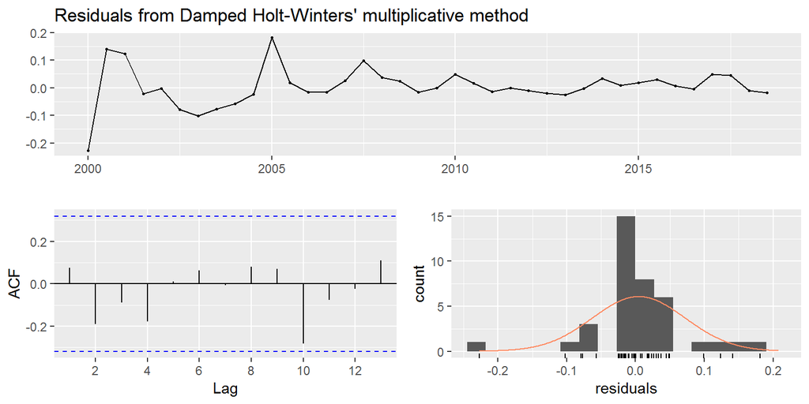

```
##
##  Ljung-Box test
##
## data:  Residuals from Damped Holt-Winters' multiplicative method
## Q* = 8.609, df = 3, p-value = 0.03497
##
## Model df: 7.   Total lags used: 10
```

### 1.4.4 Goodness of Fit

| AIC | BIC | LogLik |
| --- | --- | --- |
| 421.1228 | 434.2235 | -202.5614 |

## 1.5 Forecast 4: Seasonal ARIMA model

So far, we have restricted our attention to non-seasonal data and non-seasonal ARIMA models. However, ARIMA models are also capable of modelling a wide range of seasonal data. A seasonal ARIMA model is formed by including additional seasonal terms in the ARIMA models we have seen so far. It is written as follows: ARIMA(p,d,q)(P,D,Q)m. where m=number of observations per year. We use uppercase notation for the seasonal parts of the model, and lowercase notation for the non-seasonal parts of the model.

### 1.5.1 Graph

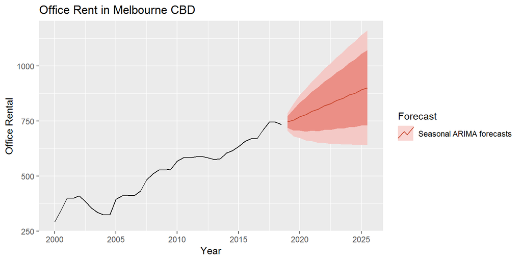

### 1.5.2 Forecast Table

| Date | Mean | Lower.80 | Lower.95 | Upper.80 | Upper.95 |
| --- | --- | --- | --- | --- | --- |
| 2019.0 | 746.6838 | 720.1074 | 706.0387 | 773.2602 | 787.3288 |
| 2019.5 | 755.5786 | 706.8844 | 681.1072 | 804.2728 | 830.0500 |
| 2020.0 | 771.0927 | 706.6744 | 672.5734 | 835.5109 | 869.6119 |
| 2020.5 | 779.9875 | 702.6504 | 661.7106 | 857.3245 | 898.2643 |
| 2021.0 | 795.5015 | 706.4566 | 659.3191 | 884.5465 | 931.6840 |
| 2021.5 | 804.3963 | 704.7631 | 652.0204 | 904.0296 | 956.7723 |
| 2022.0 | 819.9104 | 710.1646 | 652.0686 | 929.6563 | 987.7522 |
| 2022.5 | 828.8052 | 709.6061 | 646.5059 | 948.0043 | 1011.1045 |
| 2023.0 | 844.3193 | 715.8857 | 647.8971 | 972.7529 | 1040.7415 |
| 2023.5 | 853.2141 | 716.0065 | 643.3731 | 990.4217 | 1063.0551 |
| 2024.0 | 868.7282 | 722.8444 | 645.6182 | 1014.6120 | 1091.8382 |
| 2024.5 | 877.6230 | 723.4176 | 641.7861 | 1031.8284 | 1113.4598 |
| 2025.0 | 893.1371 | 730.6414 | 644.6214 | 1055.6327 | 1141.6528 |
| 2025.5 | 902.0319 | 731.5368 | 641.2822 | 1072.5269 | 1162.7816 |

### 1.5.3 Residuals

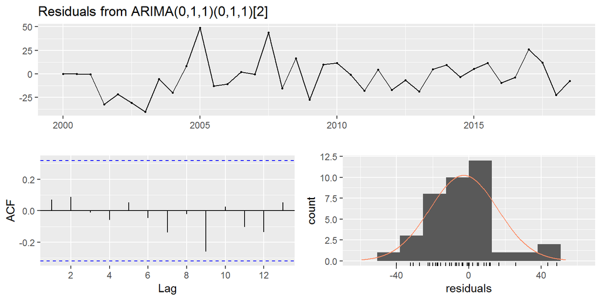

```
##
##  Ljung-Box test
##
## data:  Residuals from ARIMA(0,1,1)(0,1,1)[2]
## Q* = 0.81014, df = 3, p-value = 0.847
##
## Model df: 2.   Total lags used: 5
```

### 1.5.4 Goodness of Fit

| AIC | BIC | LogLik |
| --- | --- | --- |
| 320.3796 | 325.0457 | -157.1898 |

## 1.6 Forecast 5: ARIMA Model with Exogeneous Variables

### 1.6.1 Graph

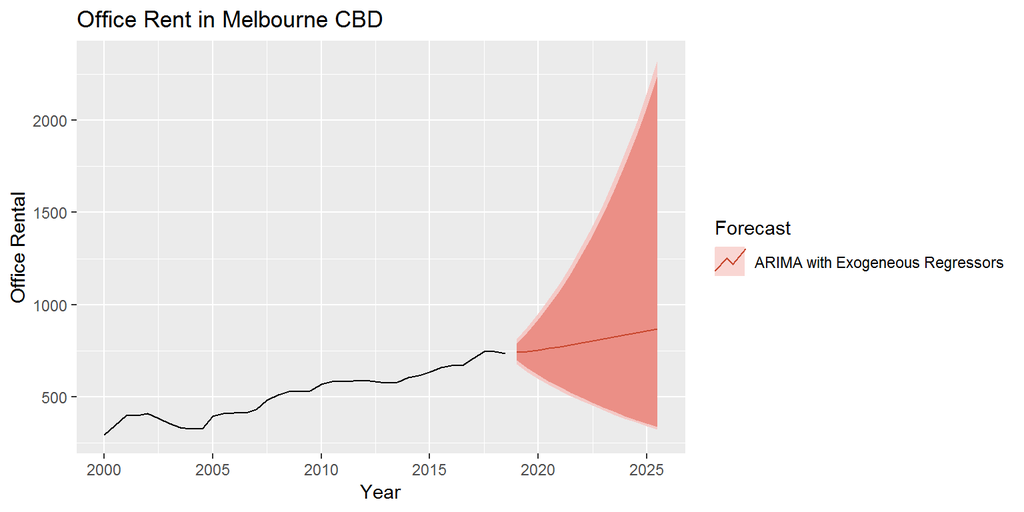

### 1.6.2 Forecast Table

| Date | Mean | Lower.80 | Lower.95 | Upper.80 | Upper.95 |
| --- | --- | --- | --- | --- | --- |
| 2019.0 | 742.1933 | 697.8390 | 675.4425 | 789.3667 | 815.5407 |
| 2019.5 | 746.4467 | 656.1898 | 633.2394 | 849.1182 | 879.8926 |
| 2020.0 | 753.8453 | 618.9575 | 596.9858 | 918.1288 | 951.9201 |
| 2020.5 | 762.6992 | 584.7842 | 563.9677 | 994.7432 | 1031.4600 |
| 2021.0 | 772.2693 | 552.9155 | 533.2230 | 1078.6455 | 1118.4812 |
| 2021.5 | 782.2305 | 522.9611 | 504.3335 | 1170.0385 | 1213.2539 |
| 2022.0 | 792.4403 | 494.7038 | 477.0823 | 1269.3692 | 1316.2543 |
| 2022.5 | 802.8366 | 468.0042 | 451.3337 | 1377.2242 | 1428.0932 |
| 2023.0 | 813.3928 | 442.7583 | 426.9872 | 1494.2866 | 1549.4796 |
| 2023.5 | 824.0983 | 418.8797 | 403.9591 | 1621.3199 | 1681.2049 |
| 2024.0 | 834.9492 | 396.2910 | 382.1750 | 1759.1622 | 1824.1386 |
| 2024.5 | 845.9451 | 374.9214 | 361.5666 | 1908.7284 | 1979.2292 |
| 2025.0 | 857.0868 | 354.7045 | 342.0698 | 2071.0131 | 2147.5080 |
| 2025.5 | 868.3755 | 335.5779 | 323.6245 | 2247.0966 | 2330.0953 |

### 1.6.3 Residuals

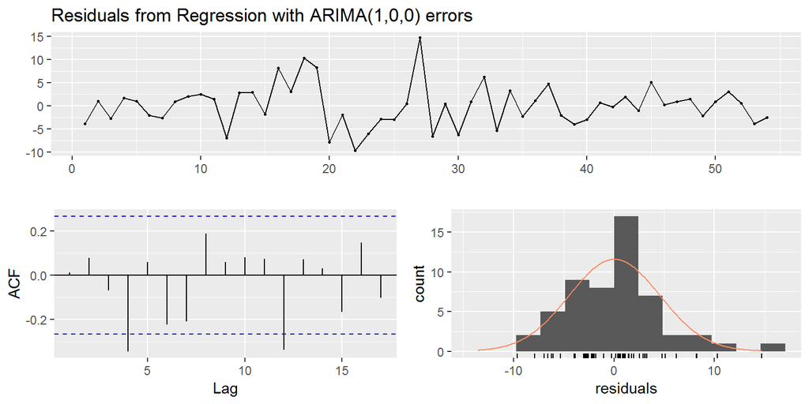

```
##
##  Ljung-Box test
##
## data:  Residuals from Regression with ARIMA(1,0,0) errors
## Q* = 16.951, df = 3, p-value = 0.0007233
##
## Model df: 7.   Total lags used: 10
```

## 1.7 Forecast: Average Across Different Models:

### 1.7.1 Graph: Rent Level

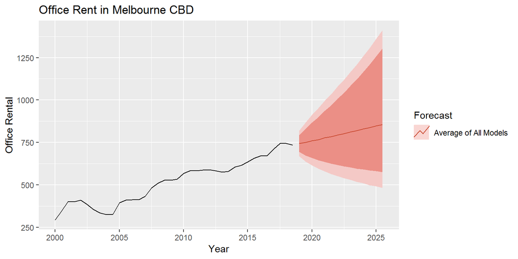

### 1.7.2 Forecast Table: Rent Level

| Date | Mean | Lower.80 | Lower.95 | Upper.80 | Upper.95 |
| --- | --- | --- | --- | --- | --- |
| 2019.0 | 744.1350 | 694.8561 | 668.9861 | 793.9777 | 820.6032 |
| 2019.5 | 750.2464 | 672.7250 | 636.6534 | 830.2508 | 867.8872 |
| 2020.0 | 760.1660 | 658.9627 | 615.2757 | 867.2484 | 913.2993 |
| 2020.5 | 767.1426 | 645.1160 | 595.1922 | 899.9950 | 953.0989 |
| 2021.0 | 777.4755 | 635.8806 | 580.2100 | 936.4749 | 996.1740 |
| 2021.5 | 784.6203 | 625.1231 | 564.4147 | 969.8252 | 1035.4512 |
| 2022.0 | 795.0614 | 618.1545 | 552.5039 | 1007.8068 | 1079.3102 |
| 2022.5 | 802.2417 | 609.2403 | 539.1874 | 1043.1541 | 1120.0467 |
| 2023.0 | 812.7337 | 603.7694 | 529.2365 | 1083.7498 | 1166.1670 |
| 2023.5 | 819.9258 | 596.1697 | 517.6382 | 1122.0824 | 1209.6068 |
| 2024.0 | 830.4594 | 591.8156 | 509.1043 | 1166.2142 | 1259.0976 |
| 2024.5 | 837.6611 | 585.2351 | 498.8068 | 1208.4392 | 1306.2966 |
| 2025.0 | 848.2368 | 581.7660 | 491.3669 | 1257.0165 | 1360.1877 |
| 2025.5 | 855.4501 | 576.0118 | 482.1046 | 1304.0732 | 1412.1894 |

### 1.7.3 Graph: Growth Rates

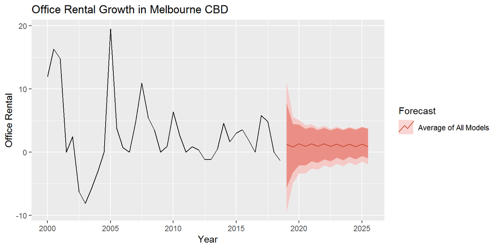

### 1.7.4 Forecast Table: Growth Rates

| Date | Mean | Lower.80 | Lower.95 | Upper.80 | Upper.95 |
| --- | --- | --- | --- | --- | --- |
| 2019.0 | 1.2351943 | -5.6165719 | -9.410722 | 7.718485 | 11.016917 |
| 2019.5 | 0.8179267 | -3.2368178 | -4.953795 | 4.467243 | 5.602208 |
| 2020.0 | 1.3135102 | -2.0669609 | -3.415489 | 4.359763 | 5.100193 |
| 2020.5 | 0.9135867 | -2.1236920 | -3.318614 | 3.706379 | 4.265495 |
| 2021.0 | 1.3379414 | -1.4419319 | -2.549417 | 3.973348 | 4.420335 |
| 2021.5 | 0.9147796 | -1.7062144 | -2.760090 | 3.499312 | 3.867054 |
| 2022.0 | 1.3219512 | -1.1210110 | -2.132883 | 3.841594 | 4.148493 |
| 2022.5 | 0.8990515 | -1.4525668 | -2.439716 | 3.447239 | 3.704820 |
| 2023.0 | 1.2993561 | -0.9020529 | -1.862778 | 3.817824 | 4.035197 |
| 2023.5 | 0.8810326 | -1.2666976 | -2.215893 | 3.475918 | 3.657302 |
| 2024.0 | 1.2765294 | -0.7330207 | -1.662358 | 3.857653 | 4.009992 |
| 2024.5 | 0.8634566 | -1.1181549 | -2.043417 | 3.556677 | 3.680086 |
| 2025.0 | 1.2546226 | -0.5945323 | -1.502771 | 3.941151 | 4.042654 |
| 2025.5 | 0.8467886 | -0.9940175 | -1.903007 | 3.675149 | 3.751863 |